# Time Series & Econometrics

### 2. Having choose the correct specification, justify the relevance of your choice with the required tests.

> Let’s perform the different quality tests of the estimated model: Let’s start by looking at the significance of the coefficients:

```r
summary(fit)
```

```
##
## Call:
## arima(x = dt1.rs, order = c(4, 0, 4))
##
## Coefficients:
##           ar1     ar2     ar3      ar4     ma1      ma2      ma3     ma4
##       -0.4566  0.8484  0.4966  -0.3088  0.1211  -1.3322  -0.1973  0.6818
## s.e.   0.1129  0.1472  0.1085   0.0827  0.0993   0.1106   0.0645  0.0661
##       intercept
##       1214.5836
## s.e.   344.6116
##
## sigma^2 estimated as 104691126:  log likelihood = -3931.52,  aic = 7883.04
##
## Training set error measures:
##                     ME     RMSE     MAE      MPE     MAPE      MASE        ACF1
## Training set -15.12718 10231.87 7173.56 43.08598 313.6634 0.5026866 0.008602246
```

```r
cat("p-values of all the coefficients for ARMA(4,4): \n")
```

```
## p-values of all the coefficients for ARMA(4,4):
```

```r
round((1-pnorm(abs(fit$coef)/sqrt(diag(fit$var.coef))))*2, 4)
```

```
##       ar1       ar2       ar3       ar4       ma1       ma2       ma3       ma4
##    0.0001    0.0000    0.0000    0.0002    0.2228    0.0000    0.0022    0.0000
## intercept
##    0.0004
```

> We can see that the coefficient ma1 is higher than 0.05 (the significance level). So we can conclude that the coefficient ma1 is not significant. All other coefficients have a p-value less than 0.05. Therefore they are significant.

> Let’s check that the model correctly predicts the future values of the time series. To do this, we can use the following metrics: - The coefficient of determination (R²) - The root mean square error (RMSE). Here, our data have the same scale so we can use the MSE.

> R²:

```r
R2 <- function(model, data) {

  predictions <- forecast(model, h = length(model$residuals))$mean
  residuals_variance <- var(model$residuals)
  data_variance <- var(data)
  r_squared <- 1 - (residuals_variance / data_variance)

  return(r_squared)
}
```

```r
rsquared <- R2(fit, dt1.rs)
print(rsquared)
```

```
## [1] 0.2777328
```

> With the automatic method:

```r
rsquared <- R2(fita, dt1.rs)
print(rsquared)
```

```
## [1] 0.31833
```

> The higher the coefficient of determination, the better the model is able to predict the data. Here, we obtain a rather low value: R²= 0.2777328. However, it is impossible to conclude on the quality of the model with this value alone: it depends on several factors. It is important to note that R² is not always a reliable indicator of the quality of the model, especially in cases where the data are noisy or contain anomalies. Here, this may explain the low value obtained. Let’s continue the analysis with the RMSE:

```r
Same_time <- function(ts1, ts2){ #Returns the modified ts2 time series

  ts1_time <- time(ts1)
  ts2_time <- time(ts2)

  ts1_start <- start(ts1)
  ts2_start <- start(ts2)
  ts2 <- ts(ts2, start = ts1_start, end = end(ts1), frequency = frequency(ts1))
  return(ts2)
}
```

```r
RMSE <- function(arima_model, data) {

  pred <- forecast(arima_model, h = length(arima_model$residuals))$mean
  predictions <- Same_time(data, pred)
  errors <- predictions - data
  rmse <- sqrt(mean(errors^2))

  return(rmse)
}
```

```r
rmse <- RMSE(fit, dt1.rs)
print(rmse)
```

```
## [1] 11956.18
```

> With the automatic method:

```r
rmse <- RMSE(fita, dt1.rs)
print(rmse)
```

```
## [1] 11994.14
```

> We obtain RMSE= 11956.18 which may seem high. The lower the RMSE value, the better the model. However, as before, this single metric is not enough to conclude about the model. Let’s now analyze the estimated residuals:

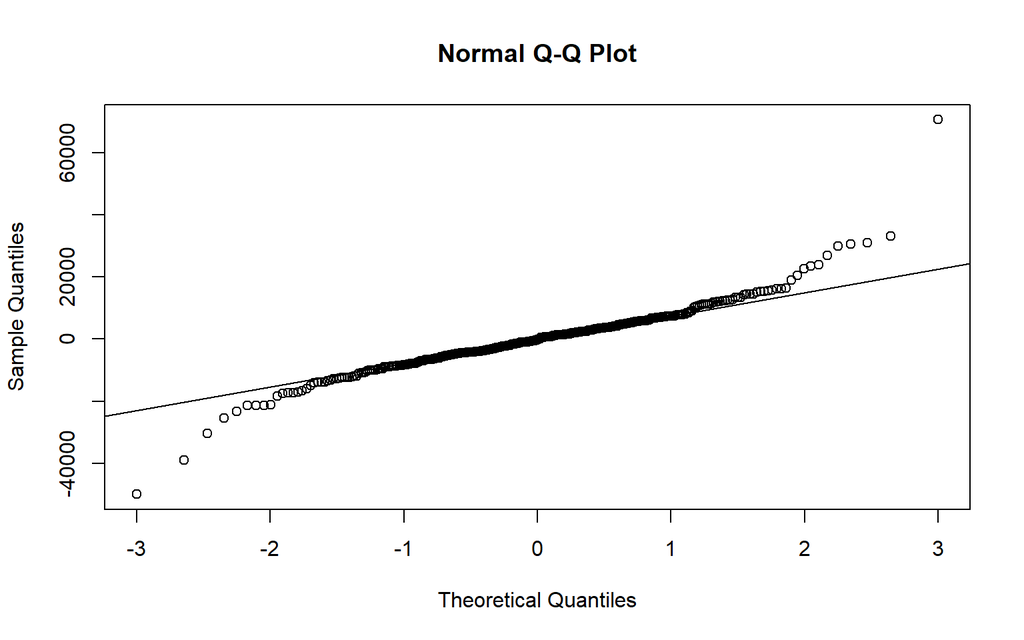

```r
qqnorm(fit$residuals)
qqline(fit$residuals)
```

```r
mean(fit$residuals)
```

```
## [1] -15.12718
```

> With the automatic method:

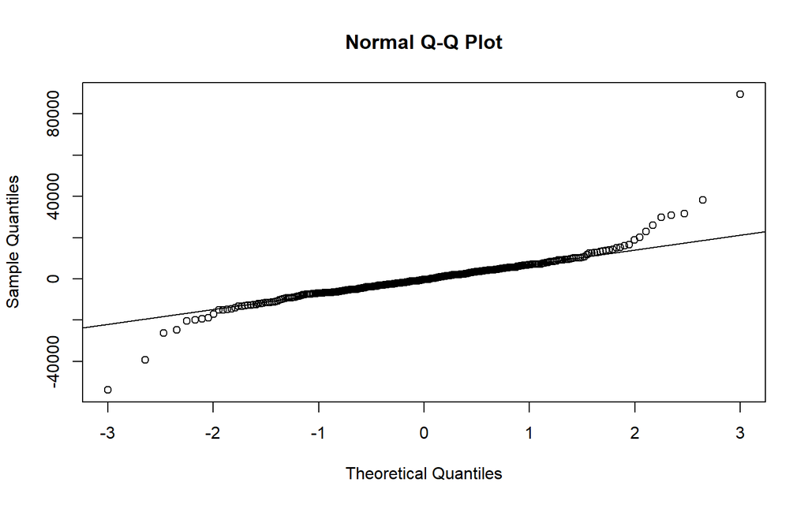

```r
qqnorm(fita$residuals)
qqline(fita$residuals)
```

```r
mean(fita$residuals)
```

```
## [1] -17.50002
```

> Let us now check the autocorrelation of the estimated residuals:

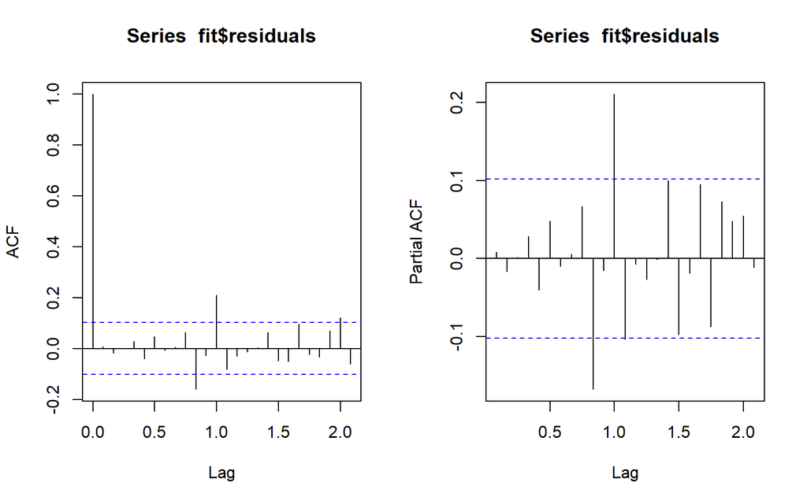

```r
par(mfrow= c(1,2))
acf(fit$residuals)
pacf(fit$residuals)
```

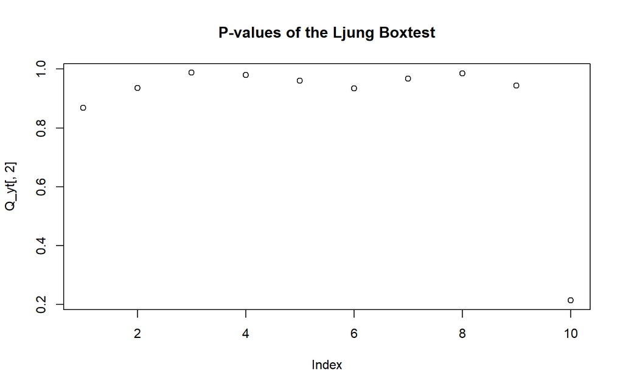

```r
Q_yt= matrix(data = 0, ncol= 2, nrow= 10)

for(i in 1:10)
{
  Q_yt[i, 1]= Box.test(fit$residuals, lag= i, type= 'Ljung')$statistic
  Q_yt[i,2]= Box.test(fit$residuals, lag= i, type= 'Ljung')$p.value

}
plot(Q_yt[,2], main= "P-values of the Ljung Boxtest")
```

> We can observe that all our p-values are above the 0.05 threshold. Therefore, the residuals of the ARMA(4,4) model are not significantly different from an independent data set. Thus, the residuals are indeed without autocorrelation. Let us now check the stationarity:

```r
ADFr <- ur.df(fit$residuals)
summary(ADFr)
```

```
##
## ###############################################
## # Augmented Dickey-Fuller Test Unit Root Test #
## ###############################################
##
## Test regression none
##
##
## Call:
## lm(formula = z.diff ~ z.lag.1 - 1 + z.diff.lag)
##
## Residuals:
##    Min     1Q Median     3Q    Max
## -49635  -5249   -113   5148  70938
##
## Coefficients:
##            Estimate Std. Error t value Pr(>|t|)
## z.lag.1    -1.00648    0.07310 -13.768   <2e-16 ***
## z.diff.lag  0.01690    0.05199   0.325    0.745
## ---
## Signif. codes:  0 '***' 0.001 '**' 0.01 '*' 0.05 '.' 0.1 ' ' 1
##
## Residual standard error: 10200 on 365 degrees of freedom
## Multiple R-squared:  0.4992, Adjusted R-squared:  0.4965
## F-statistic: 181.9 on 2 and 365 DF,  p-value: < 2.2e-16
##
##
## Value of test-statistic is: -13.7683
##
## Critical values for test statistics:
##       1pct  5pct 10pct
## tau1 -2.58 -1.95 -1.62
```

> Then, we can conclude by saying that the ARMA(4,4) model is a good model for estimating our retail sales data, according to our different metrics. We can therefore use this model to predict data.

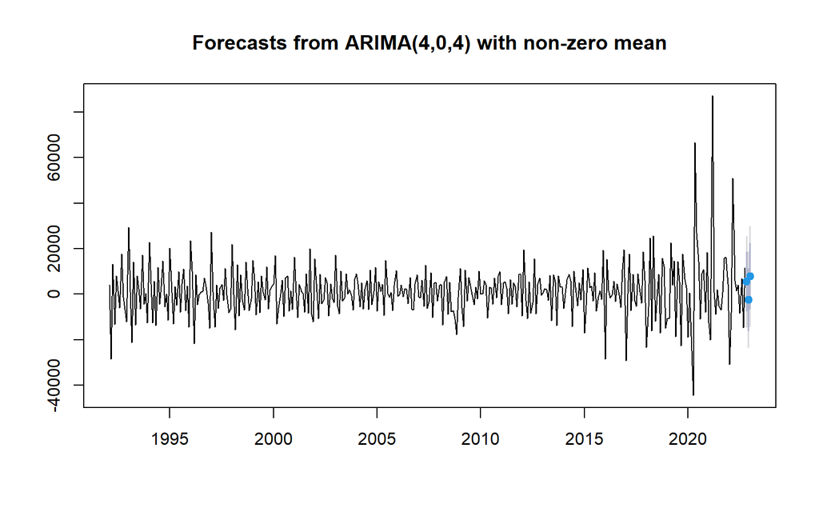

```r
fore <- forecast(fit, h= 3) #3 months predictions
plot(fore)
```

## *Exercise 4 : Estimating an ARIMA(p,d,q)*

> As seen during the class, ARIMA model were designed to deal with non stationary time series. We propose to use this kind of specification to model the Johnson & Johnson stock price from 1997 until now, on a monthly basis. Prior moving to the stock price modeling, we nee to load the data from yahoo finance website. To do so, run the following code:

```r
library(tidyquant)
jnj = tq_get("JNJ", get= "stock.prices", from ="1997-01-01")
jnj <- tq_transmute(jnj, mutate_fun= to.period, period= "months")
head(jnj)
```

```
## # A tibble: 6 × 7
##   date        open  high   low close  volume adjusted
##   <date>     <dbl> <dbl> <dbl> <dbl>   <dbl>    <dbl>
## 1 1997-01-31  28.6  29.2  28.5  28.9 5477800     15.5
## 2 1997-02-28  28.6  29.2  28.3  28.8 4997200     15.4
## 3 1997-03-31  27.5  27.7  26.4  26.4 8000400     14.2
## 4 1997-04-30  30    30.8  30    30.6 4504600     16.4
## 5 1997-05-30  29.4  30.1  29.2  30   4558800     16.2
## 6 1997-06-30  32.4  32.4  31.6  32.2 5272000     17.3
```

> We choose the close as “stock price”.

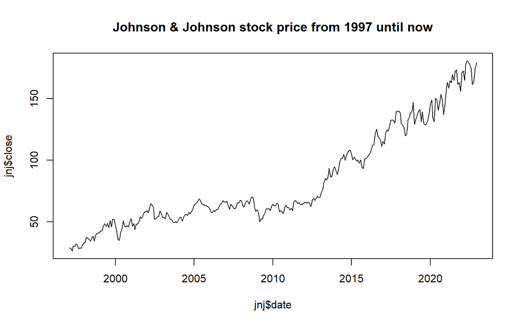

```r
plot(jnj$date, jnj$close, type= 'l', main= "Johnson & Johnson stock price from 1997 until now")
```

```r
ts.jnj <- ts(jnj$close, start= c(1997, 01, 31), frequency= 12)
```

### 1. Determine the degree of integration of the Johnson & Johnson stock prices.

> We are looking for the degree of integration of the Johnson & Johnson stock prices. So we are looking for the order of the difference filter to apply in order to make the series stationary.

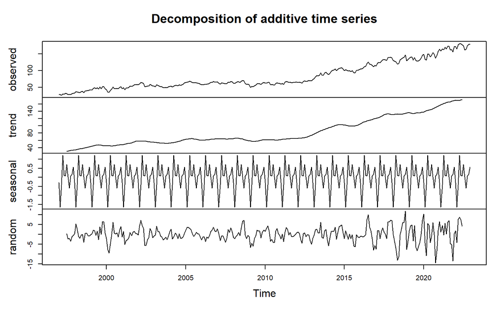

```r
dec.jnj <- decompose(ts.jnj)
plot(dec.jnj)
```

>We can observe what seems to be a seasonality. To be conservative, we first purge the time series of its assumed seasonality.

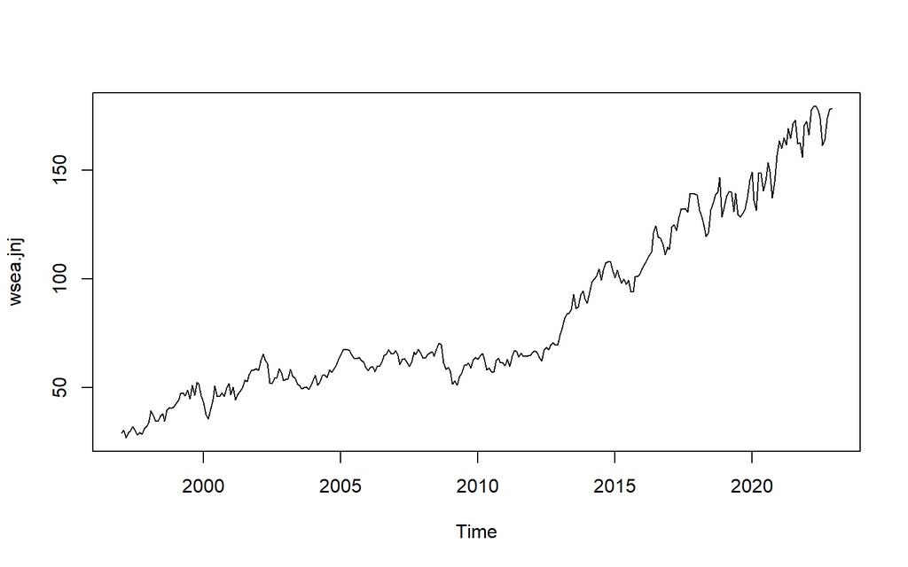

```r
library(forecast)
wsea.jnj <- seasadj(dec.jnj)
plot(wsea.jnj)
```

>As expected, the series seems to be the same as before. Thus, the suspected seasonality was not strong enough to affect the time series.As expected, the series seems to be the same as before. Thus, the suspected seasonality was not strong enough to affect the time series. Moreover, we can see a trend. Let’s proceed to the stationarity tests:

```r
library(urca)
ADF1t <- ur.df(wsea.jnj, type= "trend", lag= 1)
summary(ADF1t)
```

```
##
## ###############################################
## # Augmented Dickey-Fuller Test Unit Root Test #
## ###############################################
##
## Test regression trend
##
##
## Call:
## lm(formula = z.diff ~ z.lag.1 + 1 + tt + z.diff.lag)
##
## Residuals:
##      Min       1Q   Median       3Q      Max
## -18.0245  -2.2550   0.0945   2.3617  16.0477
##
## Coefficients:
##              Estimate Std. Error t value Pr(>|t|)
## (Intercept)  0.597335   0.554653   1.077   0.2824
## z.lag.1     -0.028276   0.015598  -1.813   0.0708 .
## tt           0.014470   0.006934   2.087   0.0377 *
## z.diff.lag  -0.070021   0.057364  -1.221   0.2232
## ---
## Signif. codes:  0 '***' 0.001 '**' 0.01 '*' 0.05 '.' 0.1 ' ' 1
##
## Residual standard error: 4.139 on 306 degrees of freedom
## Multiple R-squared:  0.02114,    Adjusted R-squared:  0.01155
## F-statistic: 2.203 on 3 and 306 DF,  p-value: 0.08774
##
##
## Value of test-statistic is: -1.8128 3.0747 2.2257
##
## Critical values for test statistics:
##       1pct  5pct 10pct
## tau3 -3.98 -3.42 -3.13
## phi2  6.15  4.71  4.05
## phi3  8.34  6.30  5.36
```

> lag= 1, is not significant and we can see a p-value higher than 0.05 our confidence level. So, let’s do it for lag= 2:

```r
ADF2t <- ur.df(wsea.jnj, type= "trend", lag= 2)
summary(ADF2t)
```

```
##
## ###############################################
## # Augmented Dickey-Fuller Test Unit Root Test #
## ###############################################
##
## Test regression trend
##
##
## Call:
## lm(formula = z.diff ~ z.lag.1 + 1 + tt + z.diff.lag)
##
## Residuals:
##      Min       1Q   Median       3Q      Max
## -17.9676  -2.0365   0.1293   2.0885  13.4707
##
## Coefficients:
##              Estimate Std. Error t value Pr(>|t|)
## (Intercept)  0.515002   0.549479   0.937  0.34937
## z.lag.1     -0.020492   0.015553  -1.318  0.18864
## tt           0.011534   0.006898   1.672  0.09557 .
## z.diff.lag1 -0.089561   0.056882  -1.575  0.11641
## z.diff.lag2 -0.182400   0.056695  -3.217  0.00143 **
## ---
## Signif. codes:  0 '***' 0.001 '**' 0.01 '*' 0.05 '.' 0.1 ' ' 1
##
## Residual standard error: 4.08 on 304 degrees of freedom
## Multiple R-squared:  0.05241,    Adjusted R-squared:  0.03994
## F-statistic: 4.203 on 4 and 304 DF,  p-value: 0.002507
##
##
## Value of test-statistic is: -1.3176 3.4125 1.5824
##
## Critical values for test statistics:
##       1pct  5pct 10pct
## tau3 -3.98 -3.42 -3.13
## phi2  6.15  4.71  4.05
## phi3  8.34  6.30  5.36
```

> The p-value is lower than our confidence level and the significance of the lag 2 is only of 2 stars. Let’s do the same test for lag= 3:

```r
ADF3t <- ur.df(wsea.jnj, type= "trend", lag= 3)
summary(ADF3t)
```

```
##
## ###############################################
## # Augmented Dickey-Fuller Test Unit Root Test #
## ###############################################
##
## Test regression trend
##
##
## Call:
## lm(formula = z.diff ~ z.lag.1 + 1 + tt + z.diff.lag)
##
## Residuals:
##      Min       1Q   Median       3Q      Max
## -17.7084  -2.1172   0.1843   2.1841  13.4787
##
## Coefficients:
##              Estimate Std. Error t value Pr(>|t|)
## (Intercept)  0.463591   0.552080   0.840 0.401731
## z.lag.1     -0.018769   0.015679  -1.197 0.232207
## tt           0.011139   0.006945   1.604 0.109797
## z.diff.lag1 -0.101547   0.058331  -1.741 0.082725 .
## z.diff.lag2 -0.190700   0.057196  -3.334 0.000962 ***
## z.diff.lag3 -0.064791   0.058106  -1.115 0.265717
## ---
## Signif. codes:  0 '***' 0.001 '**' 0.01 '*' 0.05 '.' 0.1 ' ' 1
##
## Residual standard error: 4.083 on 302 degrees of freedom
## Multiple R-squared:  0.05667,    Adjusted R-squared:  0.04106
## F-statistic: 3.629 on 5 and 302 DF,  p-value: 0.003337
##
##
## Value of test-statistic is: -1.1971 3.6022 1.5747
##
## Critical values for test statistics:
##       1pct  5pct 10pct
## tau3 -3.98 -3.42 -3.13
## phi2  6.15  4.71  4.05
## phi3  8.34  6.30  5.36
```

> Let’s apply the difference filter 1 time:

```r
d1.jnj <- diff(wsea.jnj, differences= 1)
ADF3t <- ur.df(d1.jnj, type= "trend", lag= 3)
summary(ADF3t)
```

```
##
## ###############################################
## # Augmented Dickey-Fuller Test Unit Root Test #
## ###############################################
##
## Test regression trend
##
##
## Call:
## lm(formula = z.diff ~ z.lag.1 + 1 + tt + z.diff.lag)
##
## Residuals:
##      Min       1Q   Median       3Q      Max
## -17.8228  -2.1141   0.3131   2.1492  13.5217
##
## Coefficients:
##              Estimate Std. Error t value Pr(>|t|)
## (Intercept)  0.135471   0.475845   0.285   0.7761
## z.lag.1     -1.449762   0.138688 -10.453   <2e-16 ***
## tt           0.003557   0.002653   1.341   0.1810
## z.diff.lag1  0.331640   0.115263   2.877   0.0043 **
## z.diff.lag2  0.121410   0.087510   1.387   0.1664
## z.diff.lag3  0.042956   0.058122   0.739   0.4604
## ---
## Signif. codes:  0 '***' 0.001 '**' 0.01 '*' 0.05 '.' 0.1 ' ' 1
##
## Residual standard error: 4.095 on 301 degrees of freedom
## Multiple R-squared:  0.5625, Adjusted R-squared:  0.5553
## F-statistic: 77.41 on 5 and 301 DF,  p-value: < 2.2e-16
##
##
## Value of test-statistic is: -10.4534 36.4449 54.6582
##
## Critical values for test statistics:
##       1pct  5pct 10pct
## tau3 -3.98 -3.42 -3.13
## phi2  6.15  4.71  4.05
## phi3  8.34  6.30  5.36
```

> We can suppose that the degree of integration of the Johnson & Johnson stock prices is 1. Let’s check for Phillips-Perron test and KPSS test:

> Philipps-Perron:

```r
PPt <- ur.pp(d1.jnj, type= "Z-tau", model= "trend", use.lag= 3)
summary(PPt)
```

```
##
## ##################################
## # Phillips-Perron Unit Root Test #
## ##################################
##
## Test regression with intercept and trend
##
##
## Call:
## lm(formula = y ~ y.l1 + trend)
##
## Residuals:
##      Min       1Q   Median       3Q      Max
## -18.4798  -2.1696   0.1609   2.3236  16.0209
##
## Coefficients:
##              Estimate Std. Error t value Pr(>|t|)
## (Intercept)  0.517225   0.237539   2.177   0.0302 *
## y.l1        -0.086459   0.056853  -1.521   0.1294
## trend        0.002840   0.002641   1.076   0.2830
## ---
## Signif. codes:  0 '***' 0.001 '**' 0.01 '*' 0.05 '.' 0.1 ' ' 1
##
## Residual standard error: 4.155 on 307 degrees of freedom
## Multiple R-squared:  0.01063,    Adjusted R-squared:  0.004185
## F-statistic: 1.649 on 2 and 307 DF,  p-value: 0.1939
##
##
## Value of test-statistic, type: Z-tau  is: -19.5217
##
##            aux. Z statistics
## Z-tau-mu              2.7901
## Z-tau-beta            1.0969
##
## Critical values for Z statistics:
##                      1pct      5pct     10pct
## critical values -3.991239 -3.425815 -3.135779
```

> KPSS:

```r
KPSSt <- ur.kpss(d1.jnj, type= "tau", use.lag= 3)
summary(KPSSt)
```

[output not shown]

> We can see that the value of test-statistic is below the associated critical values. So, we do not reject the null hypothesis. Hence, the time series is stationary.

> So according to the different tests, the first order difference filter is sufficient to make the series stationary. So we can conclude that the order of integration of the stock prices of Johnson & Johnson is 1: yt~I(1).

### 2. Determine the order of the ARIMA model, i.e the values of p, d, q to be used to model the stock prices. Note first, the assessment of p and q cannot be performed on the data expressed in level. Note besides, the determination of the values of p and q can be performed using different methods (graphical approach vs information criteria).

> From the previous question, we know that d= 1. Let us determine p and q:

```r
BestARIMA <- function(data, criterion, d, arstat) {
  bestAIC <- Inf
  bestBIC <- Inf
  bestCriterion <- Inf
  bestP <- -1
  bestQ <- -1

  for (p in 0:5) {
    for (q in 0:5) {

      if (arstat== TRUE){
        fit <- arima(data, order=c(p, d, q), method = "ML")
      }

      else{
        fit <- arima(data, order=c(p, d, q))
      }


      if (criterion == "aic" && fit$aic < bestAIC) {
        bestAIC <- fit$aic
        bestCriterion <- bestAIC
        bestP <- p
        bestQ <- q
      }

      if (criterion == "bic" && BIC(fit) < bestBIC) {
        bestBIC <- BIC(fit)
        bestCriterion <- bestBIC
        bestP <- p
        bestQ <- q
      }
    }
  }

  return(list(bestP, bestQ, bestCriterion))
}
```

```r
bestpqa <- BestARIMA(d1.jnj, "aic", 1, FALSE)
bestpqb <- BestARIMA(d1.jnj, "bic", 1, FALSE)

cat("\n With AIC:")
```

```
##
##  With AIC:
```

```r
cat("\n The value of p is:")
```

```
##
##  The value of p is:
```

```r
print(bestpqa[1])
```

```
## [[1]]
## [1] 5
```

```r
cat("\n The value of q is:")
```

```
##
##  The value of q is:
```

```r
print(bestpqa[2])
```

```
## [[1]]
## [1] 5
```

```r
cat("\n The corresponding AIC value is:")
```

```
##
##  The corresponding AIC value is:
```

```r
print(bestpqa[3])
```

```
## [[1]]
## [1] 1750.58
```

```r
cat("\n With BIC:")
```

```
##
##  With BIC:
```

```r
cat("\n The value of p is:")
```

```
##
##  The value of p is:
```

```r
print(bestpqb[1])
```

```
## [[1]]
## [1] 0
```

```r
cat("\n The value of q is:")
```

```
##
##  The value of q is:
```

```r
print(bestpqb[2])
```

```
## [[1]]
## [1] 3
```

```r
cat("\n The corresponding BIC value is:")
```

```
##
##  The corresponding BIC value is:
```

```r
print(bestpqb[3])
```

```
## [[1]]
## [1] 1775.818
```

> According to the AIC, we should choose an ARIMA(5,1,5) and according to the BIC, we should choose an ARIMA(0,1,3).

### 3. Estimate the corresponding ARIMA(p,d,q) model to the values of p,d,q selected previously. Check the estimated coefficients and compute the fit of the model. Plot (within the same chart) the estimated values of the stock price and the observed one.

> According to the AIC:

```r
fita <- arima(d1.jnj, order=c(5, 1, 5))
summary(fita)
```

```
##
## Call:
## arima(x = d1.jnj, order = c(5, 1, 5))
##
## Coefficients:
##           ar1      ar2     ar3     ar4     ar5      ma1      ma2      ma3
##       -0.8142  -0.3503  0.3491  0.5996  0.1668  -0.2766  -0.6386  -0.7114
## s.e.   0.1613   0.1548  0.1835  0.1532  0.0798   0.1554   0.1492   0.0835
##           ma4     ma5
##       -0.0593  0.6982
## s.e.   0.2040  0.1389
##
## sigma^2 estimated as 15.18:  log likelihood = -864.29,  aic = 1750.58
##
## Training set error measures:
##                     ME     RMSE      MAE      MPE   MAPE      MASE         ACF1
## Training set 0.1114878 3.890014 2.890347 81.85959 281.64 0.6569191 0.0007455807
```

```r
cat("p-values of all the coefficients for ARIMA(5, 1, 5): \n")
```

```
## p-values of all the coefficients for ARIMA(5, 1, 5):
```

```r
round((1-pnorm(abs(fita$coef)/sqrt(diag(fita$var.coef))))*2, 4)
```

```
##    ar1    ar2    ar3    ar4    ar5    ma1    ma2    ma3    ma4    ma5
## 0.0000 0.0237 0.0571 0.0001 0.0366 0.0752 0.0000 0.0000 0.7715 0.0000
```

> We can see that the p-values of the coefficients ar3, ma1, ma4 are greater than 0.05 (the level of significance). We can therefore conclude that these coefficients are not significant. All the other coefficients have a p-value lower than 0.05. They are therefore significant.

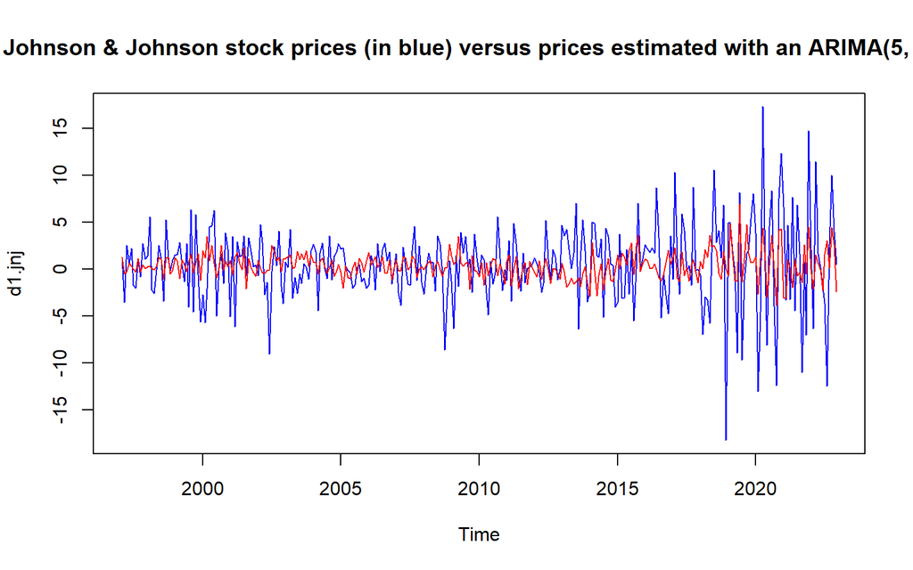

```r
plot(d1.jnj, col= "blue", main= " Johnson & Johnson stock prices (in blue) versus prices estimated with an ARIMA(5, 1, 5)")
lines(fitted(fita), col= "red")
```

> According to the BIC:

```r
fitb <- arima(d1.jnj, order=c(0, 1, 3))
summary(fitb)
```

```
##
## Call:
## arima(x = d1.jnj, order = c(0, 1, 3))
##
## Coefficients:
##           ma1      ma2     ma3
##       -1.1215  -0.0938  0.2214
## s.e.   0.0567   0.0851  0.0617
##
## sigma^2 estimated as 16.45:  log likelihood = -876.44,  aic = 1760.87
##
## Training set error measures:
##                     ME    RMSE      MAE      MPE     MAPE      MASE        ACF1
## Training set 0.1447649 4.04974 2.984768 75.82048 205.1249 0.6783791 0.005397467
```

```r
cat("p-values of all the coefficients for ARIMA(0, 1, 3): \n")
```

```
## p-values of all the coefficients for ARIMA(0, 1, 3):
```

```r
round((1-pnorm(abs(fitb$coef)/sqrt(diag(fitb$var.coef))))*2, 4)
```

```
##    ma1    ma2    ma3
## 0.0000 0.2702 0.0003
```

> We can see that the p-value of the coefficient ma2 is higher than 0.05 (the significance level). So we can conclude that the coefficient ma2 is not significant. All other coefficients have a p-value less than 0.05. Therefore they are significant.

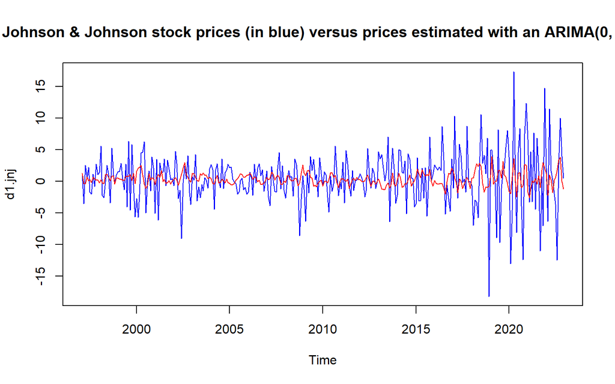

```r
plot(d1.jnj, col= "blue", main= " Johnson & Johnson stock prices (in blue) versus prices estimated with an ARIMA(0, 1, 3)")
lines(fitted(fitb), col= "red")
```

### 4. Calculate the residual of the model, given as the difference between J&ˆ J and J&J. Compute the required quality checks on the residuals.

```r
residuals <- fita$residuals
```

> Quality checks: R²:

```r
rsquared <- R2(fita, d1.jnj)
print(rsquared)
```

```
## [1] 0.1222084
```

> RMSE:

```r
rmse <- RMSE(fita, d1.jnj)
print(rmse)
```

```
## [1] 4.208752
```

> Let’s now analyze the estimated residuals:

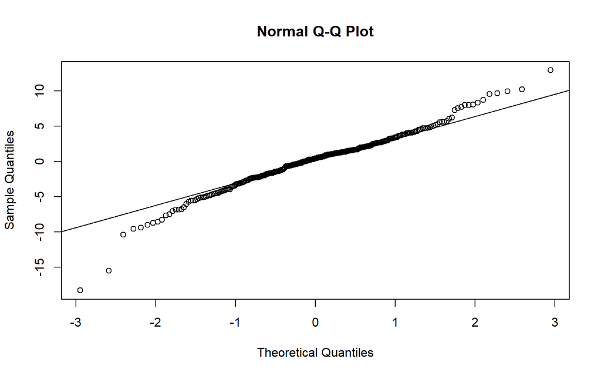

```r
qqnorm(fita$residuals)
qqline(fita$residuals)
```

```r
mean(fita$residuals)
```

```
## [1] 0.1114878
```

> Let us now check the autocorrelation of the estimated residuals:

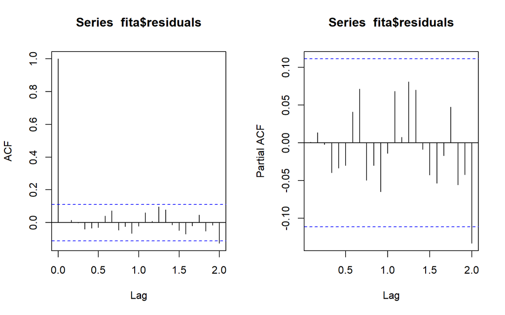

```r
par(mfrow= c(1,2))
acf(fita$residuals)
pacf(fita$residuals)
```

>With these two graphs, we can see that the residuals are not autocorrelated. Let’s check this with a Ljung Box test:

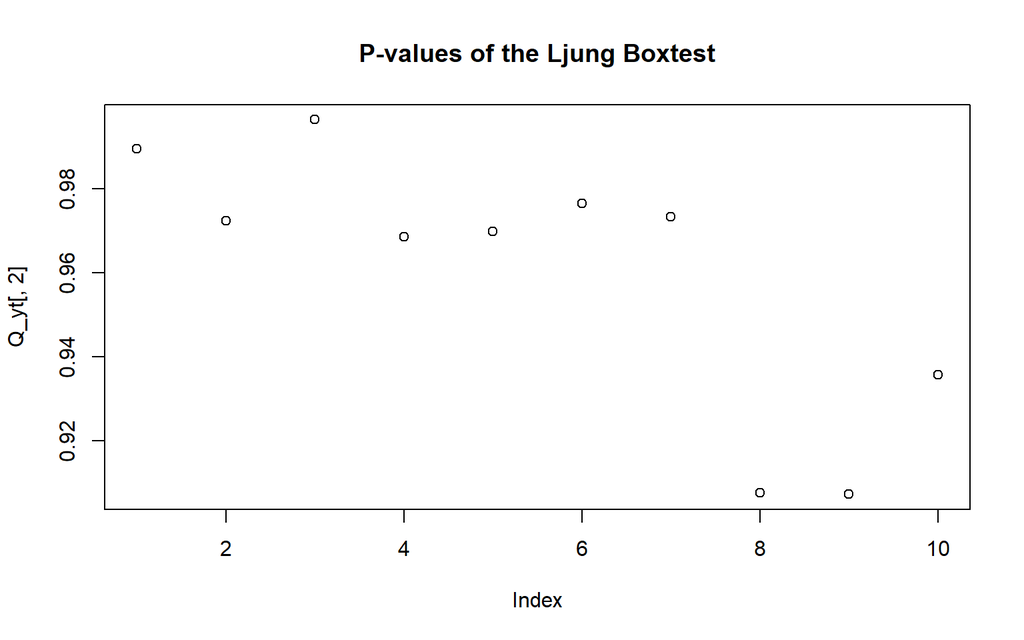

```r
Q_yt= matrix(data = 0, ncol= 2, nrow= 10)

for(i in 1:10)
{
  Q_yt[i, 1]= Box.test(fita$residuals, lag= i, type= 'Ljung')$statistic
  Q_yt[i,2]= Box.test(fita$residuals, lag= i, type= 'Ljung')$p.value

}
plot(Q_yt[,2], main= "P-values of the Ljung Boxtest")
```

```r
ADFr <- ur.df(fita$residuals)
summary(ADFr)
```

```
##
## ###############################################
## # Augmented Dickey-Fuller Test Unit Root Test #
## ###############################################
##
## Test regression none
##
##
## Call:
## lm(formula = z.diff ~ z.lag.1 - 1 + z.diff.lag)
##
## Residuals:
##      Min       1Q   Median       3Q      Max
## -18.3156  -2.0365   0.4942   2.1987  13.1034
##
## Coefficients:
##            Estimate Std. Error t value Pr(>|t|)
## z.lag.1    -0.98437    0.08068 -12.201   <2e-16 ***
## z.diff.lag -0.01413    0.05707  -0.248    0.805
## ---
## Signif. codes:  0 '***' 0.001 '**' 0.01 '*' 0.05 '.' 0.1 ' ' 1
##
## Residual standard error: 3.911 on 307 degrees of freedom
## Multiple R-squared:  0.4994, Adjusted R-squared:  0.4961
## F-statistic: 153.1 on 2 and 307 DF,  p-value: < 2.2e-16
##
##
## Value of test-statistic is: -12.2012
##
## Critical values for test statistics:
##       1pct  5pct 10pct
## tau1 -2.58 -1.95 -1.62
```

> Then, we can conclude by saying that the ARIMA(5, 1, 5) model is a good model for estimating the Johnson & Johnson stock prices, according to our different metrics. We can therefore use this model to predict data.

### 5. Using the estimated coefficients, generate a forecast over the next 3 months. Calculate the confidence interval of the forecasted points.

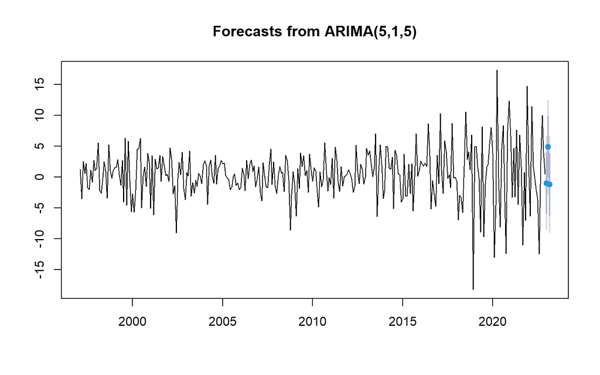

```r
fore <- forecast(fita, h= 3) #3 month predictions
plot(fore)
```

>Predictions of the Johnson & Johnson stock prices over the next 3 months:

```r
print(fore)
```

```
##          Point Forecast     Lo 80    Hi 80     Lo 95     Hi 95
## Jan 2023      -1.016936 -6.010223 3.976352 -8.653509  6.619638
## Feb 2023       4.860152 -0.153653 9.873957 -2.807801 12.528105
## Mar 2023      -1.252856 -6.357058 3.851346 -9.059060  6.553347
```

> Confidence interval of the forecasted points: The gray area on the previous graph represents the confidence interval. But let’s zoom in on it:

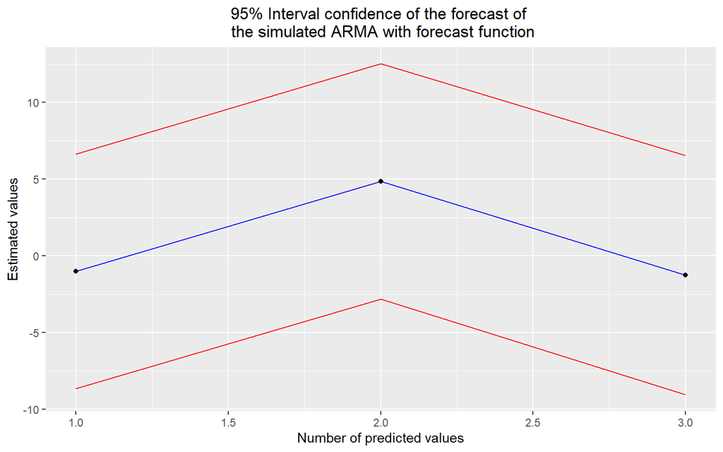

```r
library(ggplot2)
df_plot <- data.frame(fore)
col <- c("limit of the confidence interval", "forecasted values")

ggplot(df_plot, aes(x= seq(nrow(df_plot)), y= Point.Forecast)) +
  geom_line(aes(y= Lo.95), color= 'red') +
  geom_line(aes(y= Hi.95), color= 'red') +
  geom_line(aes(y= Point.Forecast), col= 'blue') +
  geom_point() +
  ggtitle("95% Interval confidence of the forecast of \n the simulated ARMA with forecast function") +
  theme(plot.title = element_text(hjust = 0.5)) +
  xlab("Number of predicted values") +
  ylab("Estimated values")
```

>Values of confidence interval:

```r
cat("The confidence interval for the 1st prediction is: [", df_plot$Lo.95[1], ",", df_plot$Hi.95[1], "]")
```

```
## The confidence interval for the 1st prediction is: [ -8.653509 , 6.619638 ]
```

```r
cat("\nThe confidence interval for the 1st prediction is: [", df_plot$Lo.95[2], ",", df_plot$Hi.95[2], "]")
```

```
##
## The confidence interval for the 1st prediction is: [ -2.807801 , 12.5281 ]
```

```r
cat("\nThe confidence interval for the 1st prediction is: [", df_plot$Lo.95[1], ",", df_plot$Hi.95[3], "]")
```

[output not shown]

> Back to the real data predictions:

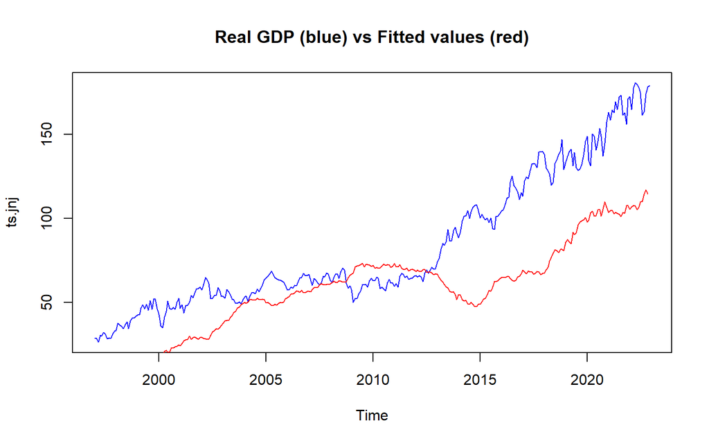

```r
tsfit <- ts(cumsum(fore$fitted), start= c(1997, 01, 31), frequency= 12)

plot(ts.jnj, col= "blue", main= "Real GDP (blue) vs Fitted values (red)")
lines(tsfit, col= "red")
```

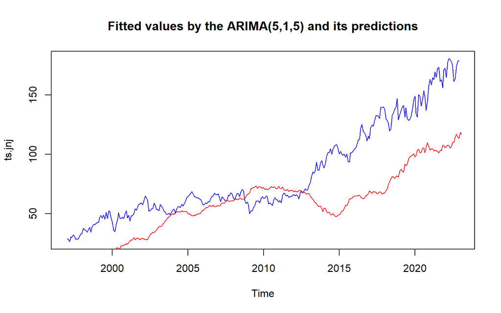

```r
fitted <- fore$fitted
fitpred <- fore$mean
pred <- c(fitted, fitpred)
cpred <- cumsum(pred)
ts.cpred <- ts(cpred, start= c(1997, 01, 31), frequency= 12)
plot(ts.jnj, main= "Fitted values by the ARIMA(5,1,5) and its predictions", col= "blue")
lines(ts.cpred, col= "red")
```

>Predicted values:

```r
tail(ts.cpred, 3)
```

```
##           Jan      Feb Mar Apr May Jun Jul Aug Sep Oct Nov      Dec
## 2022                                                       113.4607
## 2023 118.3209 117.0680
```

## *Exercise 5 : Unit root test another one*

> In this exercise, we propose to introduce a new unit root test : the test of Zivot and Andrews (1992). On of the weakness of the ADF unit root tests is their potential confusion of structural breaks in the series as evidence of non-stationarity. In other words, they may fail to reject the unit root hypothesis if the series have a structural break.

> Zivot and Andrews (1992) endogenous structural break test is a sequential test which utilizes the full sample and uses a different dummy variable for each possible break date. The break date is selected where the t-statistic from the ADF test of unit root is at a minimum (most negative). Consequently a break date will be chosen where the evidence is least favorable for the unit root null.

> The Zivot-Andrews (1992) tests state the null hypothesis is that the series has a unit root with structural break(s) against the alternative hypothesis that they are stationary with break(s). We reject Null if tvalue statistic is lower than tabulated critical value.

### 2. Generate 3 new random walks. The first one is a pure random walk, the second is a random walk with a break in level and the third on will be a random walk with both a break in level and in the trend.

```r
set.seed(1)
#Pure random walk
rw1 <- cumsum(rnorm(100))

#Random walk with a break in level
rw2 <- cumsum(rnorm(100))
rw2[50:100] <- rw2[50:100] + 5

#Random walk with both a break in level and in the trend
rw3 <- cumsum(rnorm(100))
rw3[50:100] <- rw3[50:100] + 5
rw3 <- rw3 + 1:100
```

3. Compute the appropriate Zivot and Andrews (1992) test for the generated random walk. Summarize your output within a table.

```r
za1 <- ur.za(rw1)
za2 <- ur.za(rw2, model= "intercept")
za3 <- ur.za(rw3, model= "both")


za1.stat <- za1@tstats
za2.stat <- za2@tstats
za3.stat <- za3@tstats

table <- data.frame(za1.stat, za1.stat, za1.stat)
colnames(table) <- c("rw1 test statistics", "rw2 test statistics", "rw3 test statistics")
head(table)
```

```
##   rw1 test statistics rw2 test statistics rw3 test statistics
## 1           -3.186899           -3.186899           -3.186899
## 2           -3.171887           -3.171887           -3.171887
## 3           -3.236649           -3.236649           -3.236649
## 4           -3.153430           -3.153430           -3.153430
## 5           -3.147177           -3.147177           -3.147177
## 6           -3.198532           -3.198532           -3.198532
```

```r
cvalues <- za1@cval #The critical values are the same (they are calculated for a confidence level)

za1ts <- za1@teststat #=min(table$`rw1 test statistics`)
za2ts <- za2@teststat
za3ts <- za2@teststat

cat("The critical values are:", cvalues)
```

```
## The critical values are: -5.34 -4.8 -4.58
```

```r
cat("\nrw1 test statistics:", za1ts)
```

```
##
## rw1 test statistics: -3.925157
```

```r
cat("\nrw2 test statistics:", za2ts)
```

```
##
## rw2 test statistics: -3.409388
```

```r
cat("\nrw3 test statistics:", za3ts)
```

```
##
## rw3 test statistics: -3.409388
```

### 4. Is it relevant to use such test for the filtered retail sales. Justify. Compute the Zivot and Andrews (1992) unit root test using the US retail sales.

```r
zars <- ur.za(wsea.rs, model= "trend")
summary(zars)
```

```
##
## ################################
## # Zivot-Andrews Unit Root Test #
## ################################
##
##
## Call:
## lm(formula = testmat)
##
## Residuals:
##    Min     1Q Median     3Q    Max
## -57315  -6664    -40   6536  70648
##
## Coefficients:
##              Estimate Std. Error t value Pr(>|t|)
## (Intercept) 5.026e+04  5.929e+03   8.477 5.79e-16 ***
## y.l1        6.678e-01  3.877e-02  17.225  < 2e-16 ***
## trend       2.912e+02  3.421e+01   8.514 4.45e-16 ***
## dt          1.558e+03  2.019e+02   7.714 1.17e-13 ***
## ---
## Signif. codes:  0 '***' 0.001 '**' 0.01 '*' 0.05 '.' 0.1 ' ' 1
##
## Residual standard error: 11020 on 365 degrees of freedom
##   (1 observation effacée parce que manquante)
## Multiple R-squared:  0.9896, Adjusted R-squared:  0.9895
## F-statistic: 1.153e+04 on 3 and 365 DF,  p-value: < 2.2e-16
##
##
## Teststatistic: -8.5689
## Critical values: 0.01= -4.93 0.05= -4.42 0.1= -4.11
##
## Potential break point at position: 337
```

```r
zarsd <- ur.za(dt1.rs, model= "trend")
summary(zarsd)
```

```
##
## ################################
## # Zivot-Andrews Unit Root Test #
## ################################
##
##
## Call:
## lm(formula = testmat)
##
## Residuals:
##    Min     1Q Median     3Q    Max
## -54063  -6800    331   5350  78771
##
## Coefficients:
##               Estimate Std. Error t value Pr(>|t|)
## (Intercept) -4.032e+04  2.074e+04  -1.944   0.0526 .
## y.l1        -2.884e-01  5.007e-02  -5.760  1.8e-08 ***
## trend        1.021e+04  5.218e+03   1.957   0.0511 .
## dt          -1.021e+04  5.219e+03  -1.956   0.0513 .
## ---
## Signif. codes:  0 '***' 0.001 '**' 0.01 '*' 0.05 '.' 0.1 ' ' 1
##
## Residual standard error: 11550 on 364 degrees of freedom
##   (1 observation effacée parce que manquante)
## Multiple R-squared:  0.09267,    Adjusted R-squared:  0.08519
## F-statistic: 12.39 on 3 and 364 DF,  p-value: 9.806e-08
##
##
## Teststatistic: -25.7329
## Critical values: 0.01= -4.93 0.05= -4.42 0.1= -4.11
##
## Potential break point at position: 4
```

## *Exercise 6 : Modeling the business cycle*

> Based on all your knowledge, propose the most appropriate specification to model the quarterly US GDP dynamics. Produce a forecast of the US business cycle for the next three quarters. We are expecting a complete study with illustrating charts, detailed and motivated comments and relevant results.

> Forecasting the evolution of the business cycle is a complex task that requires a thorough analysis of economic data and current economic trends. To model the quarterly US GDP dynamics, it is important to choose a model that captures the characteristics of the economic data. Let’s start by importing the data and analyzing it:

```r
gpd <- fred("GDP")
head(gpd)
```

```
##         date     GDP
## 1 1946-01-01      NA
## 2 1946-04-01      NA
## 3 1946-07-01      NA
## 4 1946-10-01      NA
## 5 1947-01-01 243.164
## 6 1947-04-01 245.968
```

```r
sum(rowSums(is.na(gpd))) #Number of rows with missing data
```

```
## [1] 4
```

> We can see that the first data are missing (NA). We therefore choose to remove them from our dataset in order to study the quarterly US GDP dynamics.

```r
gpd <- gpd[5:nrow(gpd),]
head(gpd)
```

```
##          date     GDP
## 5  1947-01-01 243.164
## 6  1947-04-01 245.968
## 7  1947-07-01 249.585
## 8  1947-10-01 259.745
## 9  1948-01-01 265.742
## 10 1948-04-01 272.567
```

> Let’s convert the dataset into time series in order to model it by an ARMA(p,q) or ARIMA(p,d,q) model:

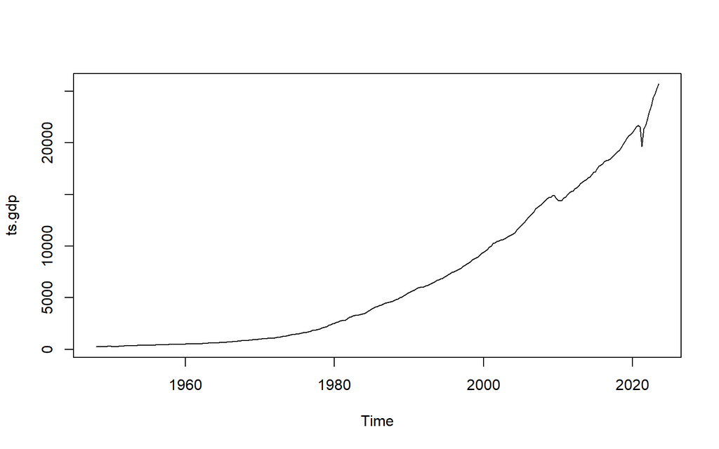

```r
ts.gdp <- ts(gpd$GDP, start= c(1948, 01), frequency= 4) #Units in billions of dollars
ts.plot(ts.gdp)
```

> After checking the FRED website (https://fred.stlouisfed.org/series/GDP#0), we get the same time series as the data. Let’s start by breaking down our series: We can observe a strong increasing trend that seems to be deterministic. Graphically, the series does not seem to show any seasonality. Let’s check:

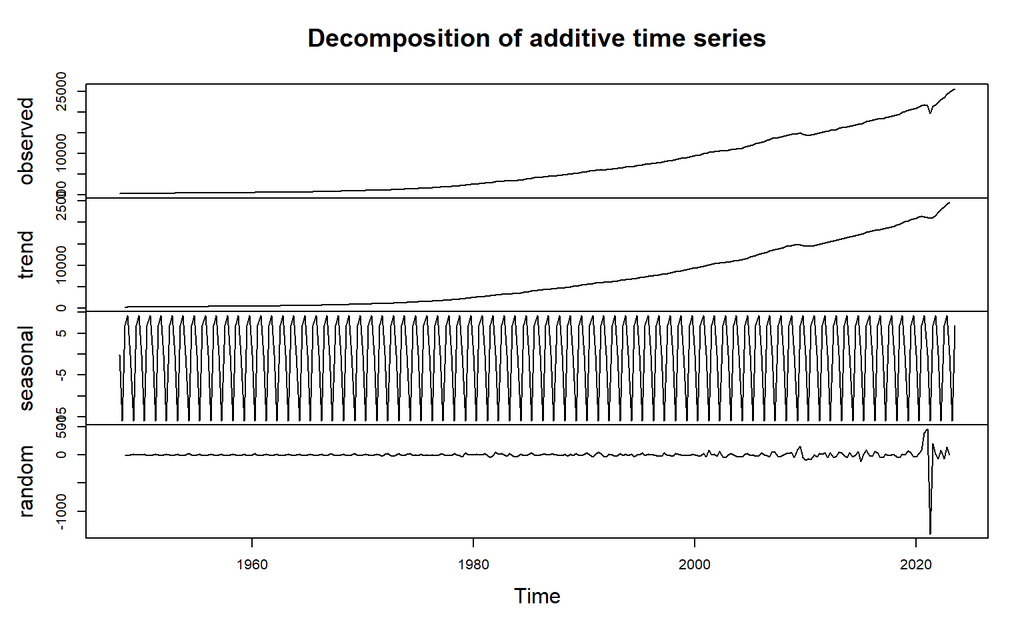

```r
dec.gdp <- decompose(ts.gdp)
plot(dec.gdp)
```

>As we can see, the series seems to have too little seasonality to affect the series, but to be on the safe side, we will purge it of this seasonality:

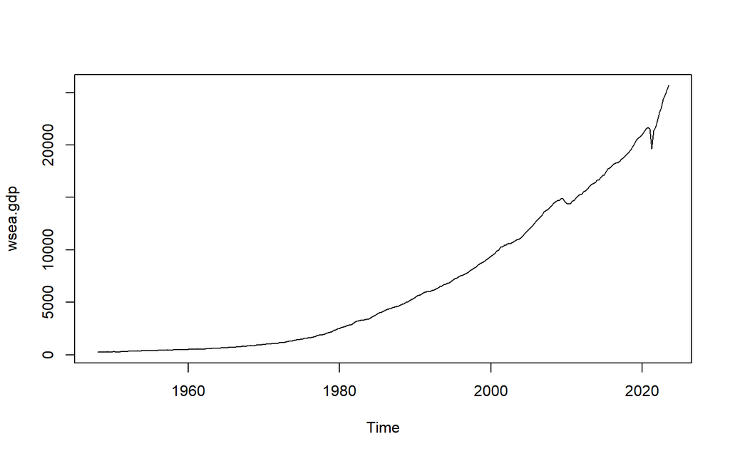

```r
wsea.gdp <- seasadj(dec.gdp)
plot(wsea.gdp)
```

>As expected, the seasonality of the series is not strong enough to affect the series. Let’s move on to the stationarity test to find out which model to use to model our data:

> Augmmented Dickey-Fuller test:

```r
ADF <- ur.df(wsea.gdp, type= "trend", lag= 1)
summary(ADF)
```

```
##
## ###############################################
## # Augmented Dickey-Fuller Test Unit Root Test #
## ###############################################
##
## Test regression trend
##
##
## Call:
## lm(formula = z.diff ~ z.lag.1 + 1 + tt + z.diff.lag)
##
## Residuals:
##      Min       1Q   Median       3Q      Max
## -2173.27   -22.43     4.10    21.71  1212.75
##
## Coefficients:
##              Estimate Std. Error t value Pr(>|t|)
## (Intercept) -0.406756  26.888098  -0.015   0.9879
## z.lag.1      0.009858   0.004141   2.380   0.0179 *
## tt           0.189422   0.322026   0.588   0.5568
## z.diff.lag  -0.127869   0.058231  -2.196   0.0289 *
## ---
## Signif. codes:  0 '***' 0.001 '**' 0.01 '*' 0.05 '.' 0.1 ' ' 1
##
## Residual standard error: 169.8 on 297 degrees of freedom
## Multiple R-squared:  0.1715, Adjusted R-squared:  0.1631
## F-statistic: 20.49 on 3 and 297 DF,  p-value: 4.257e-12
##
##
## Value of test-statistic is: 2.3804 38.5459 30.1846
##
## Critical values for test statistics:
##       1pct  5pct 10pct
## tau3 -3.98 -3.42 -3.13
## phi2  6.15  4.71  4.05
## phi3  8.34  6.30  5.36
```

> Let’s see if we can find a more significant lag:

```r
ADF <- ur.df(wsea.gdp, type= "trend", lag= 2)
summary(ADF)
```

```
##
## ###############################################
## # Augmented Dickey-Fuller Test Unit Root Test #
## ###############################################
##
## Test regression trend
##
##
## Call:
## lm(formula = z.diff ~ z.lag.1 + 1 + tt + z.diff.lag)
##
## Residuals:
##      Min       1Q   Median       3Q      Max
## -2164.30   -22.62     3.98    21.82  1262.82
##
## Coefficients:
##              Estimate Std. Error t value Pr(>|t|)
## (Intercept) -0.961097  27.266913  -0.035   0.9719
## z.lag.1      0.008987   0.004233   2.123   0.0346 *
## tt           0.186844   0.325388   0.574   0.5663
## z.diff.lag1 -0.117340   0.058872  -1.993   0.0472 *
## z.diff.lag2  0.074086   0.058971   1.256   0.2100
## ---
## Signif. codes:  0 '***' 0.001 '**' 0.01 '*' 0.05 '.' 0.1 ' ' 1
##
## Residual standard error: 169.9 on 295 degrees of freedom
## Multiple R-squared:  0.1751, Adjusted R-squared:  0.1639
## F-statistic: 15.65 on 4 and 295 DF,  p-value: 1.254e-11
##
##
## Value of test-statistic is: 2.1228 23.8633 21.3909
##
## Critical values for test statistics:
##       1pct  5pct 10pct
## tau3 -3.98 -3.42 -3.13
## phi2  6.15  4.71  4.05
## phi3  8.34  6.30  5.36
```

> Phillips-Perron test:

```r
PP <- ur.pp(wsea.gdp, type= "Z-tau", model= "trend", use.lag= 2)
summary(PP)
```

```
##
## ##################################
## # Phillips-Perron Unit Root Test #
## ##################################
##
## Test regression with intercept and trend
##
##
## Call:
## lm(formula = y ~ y.l1 + trend)
##
## Residuals:
##      Min       1Q   Median       3Q      Max
## -2121.08   -22.28     4.36    21.85  1482.77
##
## Coefficients:
##              Estimate Std. Error t value Pr(>|t|)
## (Intercept) 28.107422  29.030066   0.968    0.334
## y.l1         1.008308   0.004071 247.677   <2e-16 ***
## trend        0.200773   0.320380   0.627    0.531
## ---
## Signif. codes:  0 '***' 0.001 '**' 0.01 '*' 0.05 '.' 0.1 ' ' 1
##
## Residual standard error: 170.6 on 299 degrees of freedom
## Multiple R-squared:  0.9994, Adjusted R-squared:  0.9994
## F-statistic: 2.494e+05 on 2 and 299 DF,  p-value: < 2.2e-16
##
##
## Value of test-statistic, type: Z-tau  is: 2.2324
##
##            aux. Z statistics
## Z-tau-mu              1.0919
## Z-tau-beta            0.5980
##
## Critical values for Z statistics:
##                      1pct     5pct    10pct
## critical values -3.991979 -3.42617 -3.13599
```

> KPSS test:

```r
KPSS <- ur.kpss(wsea.gdp, type= "tau", use.lag= 2)
summary(KPSS)
```

```
##
## #######################
## # KPSS Unit Root Test #
## #######################
##
## Test is of type: tau with 2 lags.
##
## Value of test-statistic is: 2.4261
##
## Critical value for a significance level of:
##                 10pct  5pct 2.5pct  1pct
## critical values 0.119 0.146  0.176 0.216
```

> Augmmented Dickey-Fuller test:

```r
d1.gdp <- diff(wsea.gdp, differences= 1)

ADF <- ur.df(d1.gdp,type= "trend", lag= 2)
summary(ADF)
```

```
##
## ###############################################
## # Augmented Dickey-Fuller Test Unit Root Test #
## ###############################################
##
## Test regression trend
##
##
## Call:
## lm(formula = z.diff ~ z.lag.1 + 1 + tt + z.diff.lag)
##
## Residuals:
##      Min       1Q   Median       3Q      Max
## -2123.93   -23.52     0.89    24.57  1330.13
##
## Coefficients:
##              Estimate Std. Error t value Pr(>|t|)
## (Intercept) -36.45887   20.37823  -1.789   0.0746 .
## z.lag.1      -0.90405    0.10563  -8.558 6.46e-16 ***
## tt            0.74995    0.14114   5.314 2.13e-07 ***
## z.diff.lag1  -0.19700    0.08760  -2.249   0.0253 *
## z.diff.lag2  -0.09133    0.05880  -1.553   0.1215
## ---
## Signif. codes:  0 '***' 0.001 '**' 0.01 '*' 0.05 '.' 0.1 ' ' 1
##
## Residual standard error: 170.8 on 294 degrees of freedom
## Multiple R-squared:  0.5582, Adjusted R-squared:  0.5522
## F-statistic: 92.86 on 4 and 294 DF,  p-value: < 2.2e-16
##
##
## Value of test-statistic is: -8.5583 24.501 36.693
##
## Critical values for test statistics:
##       1pct  5pct 10pct
## tau3 -3.98 -3.42 -3.13
## phi2  6.15  4.71  4.05
## phi3  8.34  6.30  5.36
```

> Phillips-Perron test:

```r
PP <- ur.pp(d1.gdp, type= "Z-tau", model= "trend", use.lag= 2)
summary(PP)
```

```
##
## ##################################
## # Phillips-Perron Unit Root Test #
## ##################################
##
## Test regression with intercept and trend
##
##
## Call:
## lm(formula = y ~ y.l1 + trend)
##
## Residuals:
##      Min       1Q   Median       3Q      Max
## -2121.86   -25.04    -0.76    26.70  1286.96
##
## Coefficients:
##             Estimate Std. Error t value Pr(>|t|)
## (Intercept) 92.63859   10.96114   8.452 1.29e-15 ***
## y.l1        -0.10349    0.05777  -1.791   0.0742 .
## trend        0.89925    0.12253   7.339 2.06e-12 ***
## ---
## Signif. codes:  0 '***' 0.001 '**' 0.01 '*' 0.05 '.' 0.1 ' ' 1
##
## Residual standard error: 171.1 on 298 degrees of freedom
## Multiple R-squared:  0.1557, Adjusted R-squared:   0.15
## F-statistic: 27.48 on 2 and 298 DF,  p-value: 1.116e-11
##
##
## Value of test-statistic, type: Z-tau  is: -19.044
##
##            aux. Z statistics
## Z-tau-mu              7.8342
## Z-tau-beta            7.3178
##
## Critical values for Z statistics:
##                      1pct      5pct     10pct
## critical values -3.992074 -3.426215 -3.136017
```

> KPSS test:

```r
KPSS <- ur.kpss(d1.gdp, type= "tau", use.lag= 2)
summary(KPSS)
```

```
##
## #######################
## # KPSS Unit Root Test #
## #######################
##
## Test is of type: tau with 2 lags.
##
## Value of test-statistic is: 0.1279
##
## Critical value for a significance level of:
##                 10pct  5pct 2.5pct  1pct
## critical values 0.119 0.146  0.176 0.216
```

> we can see that the value of test-statistic is lower than the critical values for a risk of 5%. Then, we do not reject the null hypothesis. Hence, the series is stationary for a risk of 5%. So, as we have just seen with the different unit root tests, the first order difference filter is sufficient to stationarize the time series. Thus, the degree of integration d= 1. So we are looking for an ARIMA(p,1,q). Let us look for the best values of p and q:

```r
bestpqa <- BestARIMA(d1.gdp, "aic", 1, TRUE)
bestpqb <- BestARIMA(d1.gdp, "bic", 1, TRUE)
cat("\n With AIC:")
```

```
##
##  With AIC:
```

```r
cat("\n The value of p is:")
```

```
##
##  The value of p is:
```

```r
print(bestpqa[1])
```

```
## [[1]]
## [1] 0
```

```r
cat("\n The value of q is:")
```

```
##
##  The value of q is:
```

```r
print(bestpqa[2])
```

```
## [[1]]
## [1] 3
```

```r
cat("\n The corresponding AIC value is:")
```

```
##
##  The corresponding AIC value is:
```

```r
print(bestpqa[3])
```

```
## [[1]]
## [1] 3962.462
```

```r
cat("\n With BIC:")
```

```
##
##  With BIC:
```

```r
cat("\n The value of p is:")
```

```
##
##  The value of p is:
```

```r
print(bestpqb[1])
```

```
## [[1]]
## [1] 0
```

```r
cat("\n The value of q is:")
```

```
##
##  The value of q is:
```

```r
print(bestpqb[2])
```

```
## [[1]]
## [1] 1
```

```r
cat("\n The corresponding BIC value is:")
```

```
##
##  The corresponding BIC value is:
```

```r
print(bestpqb[3])
```

```
## [[1]]
## [1] 3973.335
```

> According to the AIC, we should choose an ARIMA(0,1,3) and according to the BIC, we should choose an ARIMA(0,1,1).

> According to the AIC:

```r
fita <- arima(d1.gdp, order=c(0, 1, 3))
summary(fita)
```

```
##
## Call:
## arima(x = d1.gdp, order = c(0, 1, 3))
##
## Coefficients:
##           ma1     ma2     ma3
##       -1.0681  0.2264  -0.100
## s.e.   0.0577  0.0858   0.058
##
## sigma^2 estimated as 29508:  log likelihood = -1977.23,  aic = 3962.46
##
## Training set error measures:
##                    ME     RMSE      MAE       MPE    MAPE      MASE
## Training set 16.62213 171.4932 58.63297 -66.06188 200.173 0.8278721
##                      ACF1
## Training set -0.008989279
```

```r
cat("p-values of all the coefficients for ARIMA(0, 1, 3): \n")
```

```
## p-values of all the coefficients for ARIMA(0, 1, 3):
```

```r
round((1-pnorm(abs(fita$coef)/sqrt(diag(fita$var.coef))))*2, 4)
```

```
##    ma1    ma2    ma3
## 0.0000 0.0084 0.0847
```

> All the coefficients have a p-value lower than 0.05 except the ma3 coefficient. Thus, ma1 and ma2 coefficient are significant.

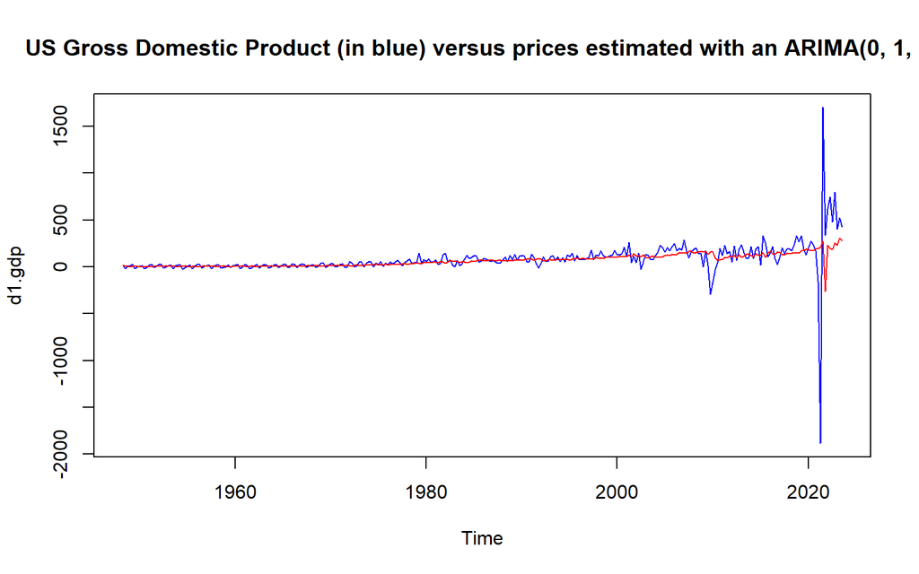

```r
plot(d1.gdp, col= "blue", main= "US Gross Domestic Product (in blue) versus prices estimated with an ARIMA(0, 1, 3)")
lines(fitted(fita), col= "red")
```

> According to the BIC:

```r
fitb <- arima(d1.gdp, order=c(0, 1, 1))
summary(fitb)
```

```
##
## Call:
## arima(x = d1.gdp, order = c(0, 1, 1))
##
## Coefficients:
##           ma1
##       -0.9462
## s.e.   0.0200
##
## sigma^2 estimated as 30247:  log likelihood = -1980.96,  aic = 3965.92
##
## Training set error measures:
##                    ME     RMSE      MAE       MPE     MAPE      MASE       ACF1
## Training set 17.17321 173.6284 57.37114 -52.73099 180.8948 0.8100556 -0.1373774
```

```r
cat("p-values of all the coefficients for ARIMA(0, 1, 1): \n")
```

```
## p-values of all the coefficients for ARIMA(0, 1, 1):
```

```r
round((1-pnorm(abs(fitb$coef)/sqrt(diag(fitb$var.coef))))*2, 4)
```

```
## ma1
##   0
```

> The only ma1 coefficient is significant.

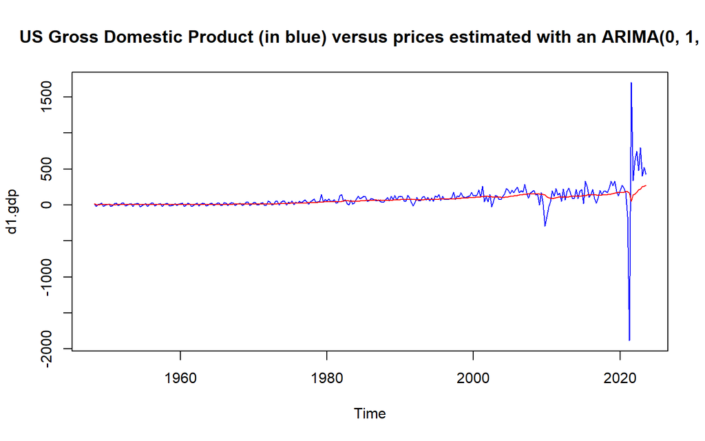

```r
plot(d1.gdp, col= "blue", main= "US Gross Domestic Product (in blue) versus prices estimated with an ARIMA(0, 1, 1)")
lines(fitted(fitb), col= "red")
```

>Let’s try automatically:

```r
fitauto <- auto.arima(d1.gdp)
summary(fitauto)
```

```
## Series: d1.gdp
## ARIMA(0,1,2) with drift
##
## Coefficients:
##           ma1     ma2   drift
##       -1.0684  0.0977  0.9305
## s.e.   0.0531  0.0573  0.3964
##
## sigma^2 = 29634:  log likelihood = -1976.73
## AIC=3961.45   AICc=3961.59   BIC=3976.28
##
## Training set error measures:
##                     ME     RMSE      MAE       MPE     MAPE      MASE
## Training set -1.637937 171.0022 58.01698 -154.3175 313.7295 0.8053535
##                     ACF1
## Training set -0.01408141
```

> So, we should estimate our series with an ARIMA(0,1,2) according the automatic function.

```r
cat("p-values of all the coefficients for ARIMA(0, 1, 2): \n")
```

```
## p-values of all the coefficients for ARIMA(0, 1, 2):
```

```r
round((1-pnorm(abs(fitauto$coef)/sqrt(diag(fitauto$var.coef))))*2, 4)
```

```
##    ma1    ma2  drift
## 0.0000 0.0881 0.0189
```

> Only the ma2 coefficient is not significant because its p-value is higer than 0.05.

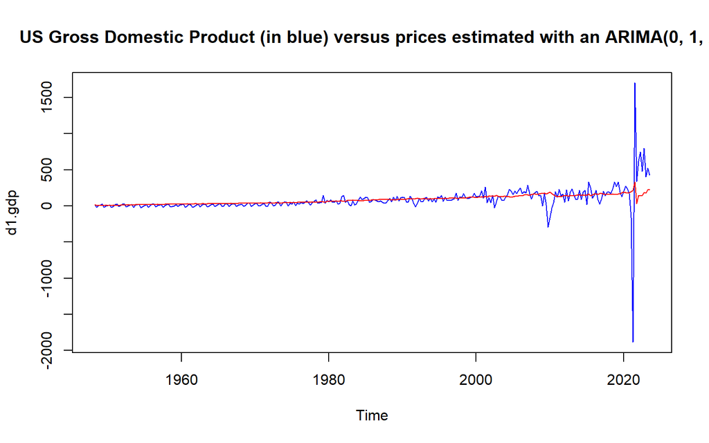

```r
plot(d1.gdp, col= "blue", main= "US Gross Domestic Product (in blue) versus prices estimated with an ARIMA(0, 1, 2)")
lines(fitted(fitauto), col= "red")
```

>It is very difficult to choose the right ARIMA model. Let’s compute the different metrics:

> Quality checks: R²:

```r
r2a <- R2(fita, d1.gdp)
r2b <- R2(fitb, d1.gdp)
r2auto <- R2(fitauto, d1.gdp)

cat("The R² of the ARIMA(0, 1, 3):", r2a)
```

```
## The R² of the ARIMA(0, 1, 3): 0.1492369
```

```r
cat("\nThe R² of the ARIMA(0, 1, 1):", r2b)
```

```
##
## The R² of the ARIMA(0, 1, 1): 0.1282612
```

```r
cat("\nThe R² of the ARIMA(0, 1, 2):", r2auto)
```

```
##
## The R² of the ARIMA(0, 1, 2): 0.1461579
```

```r
r2 <- c(r2a, r2b, r2auto)
```

> RMSE:

```r
rmsea <- RMSE(fita, d1.jnj)
rmseb <- RMSE(fitb, d1.jnj)
rmseauto <- RMSE(fitauto, d1.jnj)

cat("The RMSE of the ARIMA(0, 1, 3):", rmsea)
```

[output not shown]

```r
cat("\nThe RMSE of the ARIMA(0, 1, 1):", rmseb)
```

[output not shown]

```r
cat("\nThe RMSE of the ARIMA(0, 1, 2):", rmseauto)
```

[output not shown]

```r
rmse <- c(rmsea, rmseb, rmseauto)
```

> Let’s now analyze the estimated residuals:

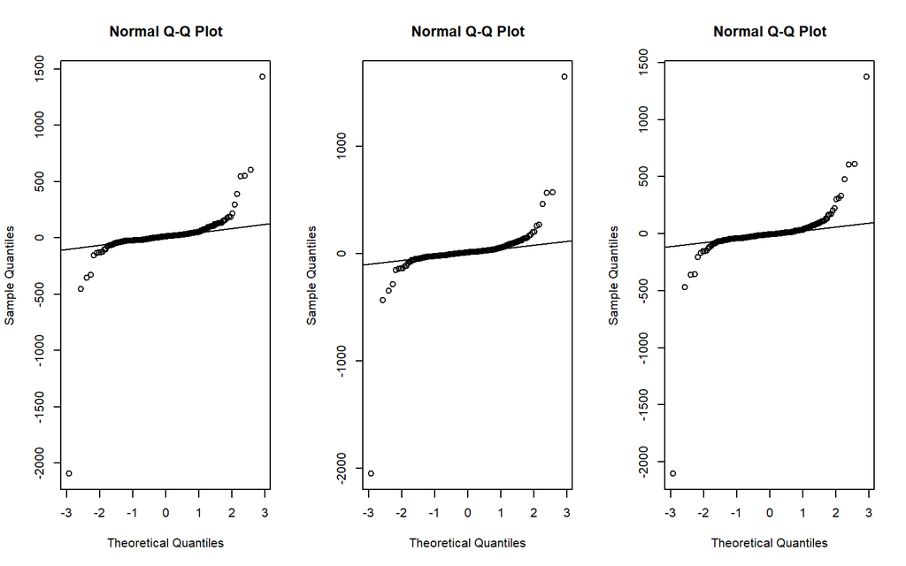

```r
par(mfrow= c(1,3))
qqnorm(fita$residuals)
qqline(fita$residuals)

qqnorm(fitb$residuals)
qqline(fitb$residuals)

qqnorm(fitauto$residuals)
qqline(fitauto$residuals)
```

```r
qq <- rep(TRUE, 3)

meana <- mean(fita$residuals)
meanb <- mean(fitb$residuals)
meanauto <- mean(fitauto$residuals)

cat("The average of the ARIMA(0, 1, 3) residuals:", meana)
```

```
## The average of the ARIMA(0, 1, 3) residuals: 16.62213
```

```r
cat("\nThe average of the ARIMA(0, 1, 1) residuals:", meanb)
```

```
##
## The average of the ARIMA(0, 1, 1) residuals: 17.17321
```

```r
cat("\nThe average of the ARIMA(0, 1, 2) residuals:", meanauto)
```

```
##
## The average of the ARIMA(0, 1, 2) residuals: -1.637937
```

```r
mean <- c(meana, meanb, meanauto)
```

> Let us now check the autocorrelation of the estimated residuals:

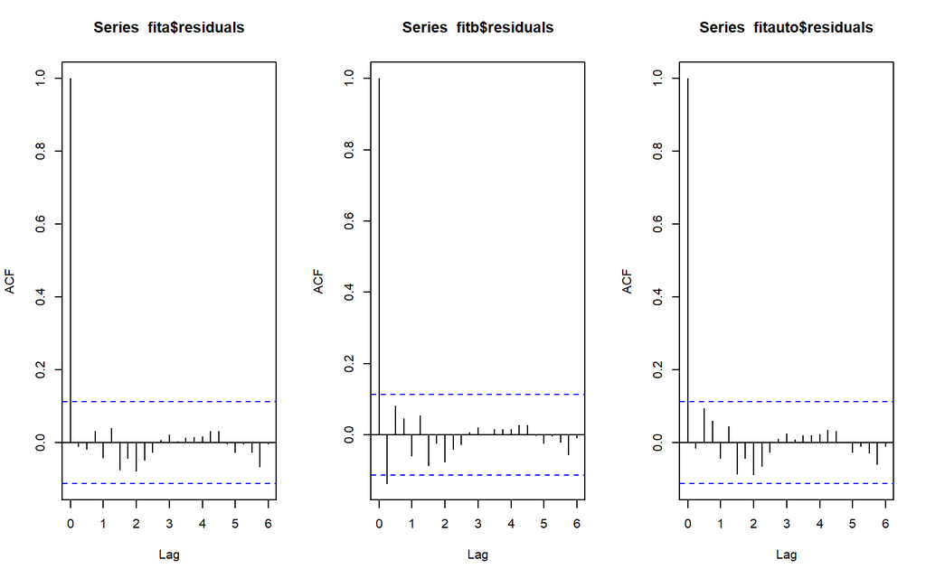

```r
par(mfrow= c(1,3))
acf(fita$residuals)
acf(fitb$residuals)
acf(fitauto$residuals)
```